# Homework3

## Deseasonalization and Detrending Phase

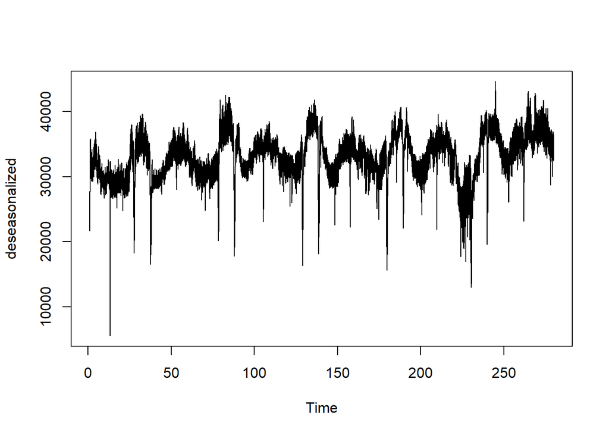

```r
deseasonalized<-ts168-decomposed168$seasonal
ts.plot(deseasonalized)
```

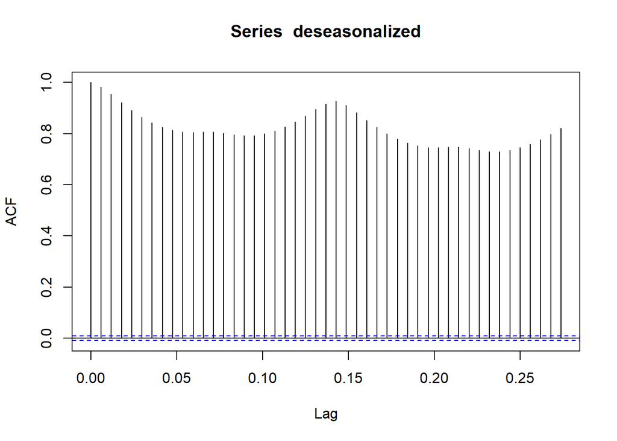

```r
acf(deseasonalized)
```

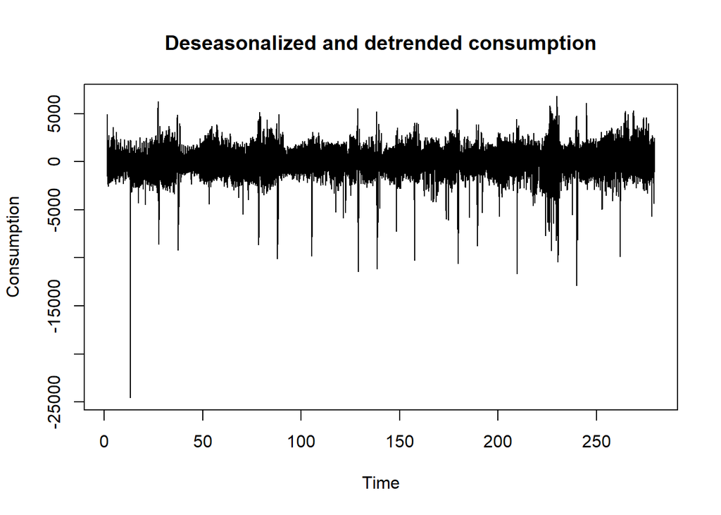

```r
detrend<-deseasonalized-decomposed168$trend
ts.plot(detrend, xlab = "Time", ylab = "Consumption",main="Deseasonalized and detrended consumption")
```

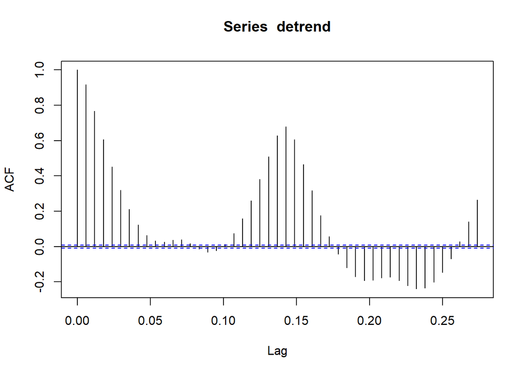

```r
acf(detrend,na.action = na.pass)
```

## Applying AR models

```r
random<-decomposed168$random
ar_model1<-arima(random,order = c(1,0,0))
ar_model2<-arima(random,order = c(2,0,0))
ar_model3<-arima(random,order = c(3,0,0))
print(ar_model1)
```

```
##
## Call:
## arima(x = random, order = c(1, 0, 0))
##
## Coefficients:
##          ar1  intercept
##       0.9166     0.1335
## s.e.  0.0018    32.6277
##
## sigma^2 estimated as 345531:  log likelihood = -364075.2,  aic = 728156.5
```

```r
print(ar_model2)
```

```
##
## Call:
## arima(x = random, order = c(2, 0, 0))
##
## Coefficients:
##          ar1      ar2  intercept
##       1.3304  -0.4515     0.1329
## s.e.  0.0041   0.0041    20.0471
##
## sigma^2 estimated as 275099:  log likelihood = -358752.4,  aic = 717512.9
```

```r
print(ar_model3)
```

```
##
## Call:
## arima(x = random, order = c(3, 0, 0))
##
## Coefficients:
##          ar1      ar2      ar3  intercept
##       1.3231  -0.4297  -0.0164     0.1330
## s.e.  0.0046   0.0074   0.0046    19.7276
##
## sigma^2 estimated as 275026:  log likelihood = -358746.2,  aic = 717502.3
```

The best AIC value is reached in ar_model3

## Applying MA models

```r
ma_model1<-arima(random,order = c(0,0,1))
ma_model2<-arima(random,order = c(0,0,2))
ma_model3<-arima(random,order = c(0,0,3))
print(ma_model1)
```

```
##
## Call:
## arima(x = random, order = c(0, 0, 1))
##
## Coefficients:
##          ma1  intercept
##       0.8526     0.1322
## s.e.  0.0018     7.5284
##
## sigma^2 estimated as 771235:  log likelihood = -382824.6,  aic = 765655.2
```

```r
print(ma_model2)
```

```
##
## Call:
## arima(x = random, order = c(0, 0, 2))
##
## Coefficients:
##          ma1     ma2  intercept
##       1.2006  0.6132     0.1325
## s.e.  0.0037  0.0029     8.8326
##
## sigma^2 estimated as 460211:  log likelihood = -370768,  aic = 741544
```

```r
print(ma_model3)
```

```
##
## Call:
## arima(x = random, order = c(0, 0, 3))
##
## Coefficients:
##          ma1     ma2     ma3  intercept
##       1.2840  1.0060  0.4754     0.1326
## s.e.  0.0043  0.0047  0.0035    10.3246
##
## sigma^2 estimated as 351169:  log likelihood = -364453.3,  aic = 728916.7
```

The best AIC value is reached in ma_model3

## Applyin ARMA models

I will test 4 models which are ARIMA(3,0,3), ARIMA(3,0,2), ARIMA(2,0,3),and ARIMA(2,0,2)

```r
model1<-arima(random,order = c(3,0,3))
model2<-arima(random,order = c(3,0,2))
model3<-arima(random,order = c(2,0,3))
model4<-arima(random,order = c(2,0,2))
print(model1)
```

```
##
## Call:
## arima(x = random, order = c(3, 0, 3))
##
## Coefficients:
```

```
##          ar1     ar2      ar3     ma1      ma2      ma3  intercept
##       1.0233  0.0506  -0.2256  0.2997  -0.1004  -0.0060     0.1770
## s.e.     NaN     NaN      NaN     NaN   0.0157   0.0084    19.0702
##
## sigma^2 estimated as 274654:  log likelihood = -358714.6,  aic = 717445.1
```

```r
print(model2)
```

```
##
## Call:
## arima(x = random, order = c(3, 0, 2))
##
## Coefficients:
##          ar1     ar2      ar3     ma1      ma2  intercept
##       0.6034  0.6003  -0.4081  0.7197  -0.0901     0.1955
## s.e.  0.0302  0.0359   0.0131  0.0307   0.0111    19.3357
##
## sigma^2 estimated as 274518:  log likelihood = -358703,  aic = 717420.1
```

```r
print(model3)
```

```
##
## Call:
## arima(x = random, order = c(2, 0, 3))
##
## Coefficients:
##          ar1      ar2      ma1      ma2     ma3  intercept
##       1.4170  -0.5285  -0.0934  -0.0423  0.0173     0.3884
## s.e.  0.0277   0.0226   0.0282   0.0150  0.0079    19.1822
##
## sigma^2 estimated as 274726:  log likelihood = -358720.7,  aic = 717455.4
```

```r
print(model4)
```

```
##
## Call:
## arima(x = random, order = c(2, 0, 2))
##
## Coefficients:
```

```
##          ar1     ar2     ma1     ma2  intercept
##       0.1541  0.6118  1.1293  0.3187     0.1812
## s.e.     NaN     NaN     NaN     NaN    25.8596
##
## sigma^2 estimated as 285707:  log likelihood = -359635.9,  aic = 719283.8
```

The best AIC value is in model2 which is ARIMA(3,0,2)

## Forecasting

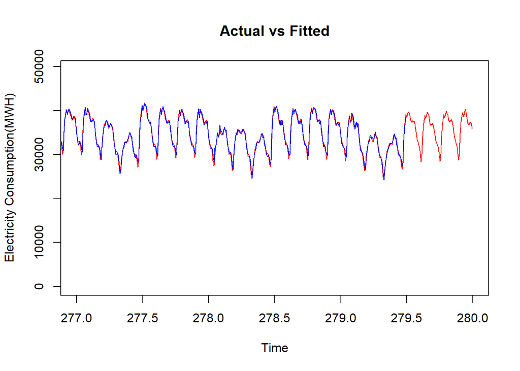

```r
fitted<-random-residuals(model2)+decomposed168$seasonal+decomposed168$trend
#tail(fitted,90)
forecast_cons<-predict(model2,n.ahead = 336+84)$pred
forecast_ts<-ts(forecast_cons,frequency=168,start=c(279,85))
plot(ts168, ylab = "Electricity Consumption(MWH)",main ="Actual vs Fitted",col="red",xlim=c(277,280))
points(fitted, type = "l", col = "blue",  xlim=c(277,280))
```

Reds are actual values and blues are fitted values. I only visualized last part of the data to make it seem more clear. Now let’s add trend and seasonality to our forecasted values.

```r
trend = tail(decomposed168$trend[!is.na(decomposed168$trend)],1)
tail(decomposed168$seasonal,1)
```

```
## Time Series:
## Start = c(279, 168)
## End = c(279, 168)
## Frequency = 168
## [1] 1085.391
```

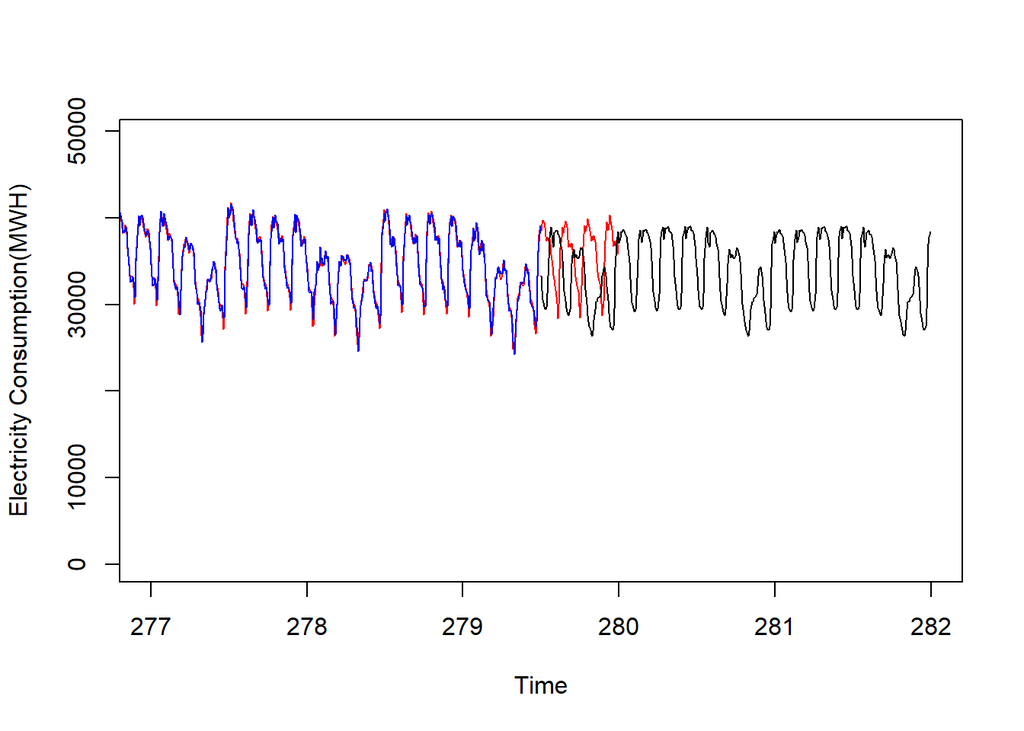

```r
seasonality = decomposed168$seasonal[1:420]
forecast2 = forecast_ts + trend + seasonality
plot(ts168, ylab = "Electricity Consumption(MWH)",col = "red",xlim=c(277,282))
points(fitted, type = "l", col = "blue", xlim=c(277,282))
points(forecast2, type = "l", col = "black")
```

Last 336 observations are observations are observations of last 14 days which are to be forecasted. In order to find the error rate I will compare them with my test set.

```r
last14_forecast<-tail(forecast2,336)
forecast_table<-data.table(forecasted_values=last14_forecast)
forecast_table = forecast_table[,actual_values:=test_set]
datefor = seq(from = as.Date("2017-05-07"), to = as.Date("2017-05-20"), by = 'day')
hourfor = seq(from = 0, to = 23)
forecast_table = forecast_table[,date:=rep(datefor,each=24)]
forecast_table = forecast_table[,hour:=rep(hourfor,14)]
forecast_table = forecast_table[,datewithhour:=ymd(date)+dhours(hour)]
daily_table<-forecast_table[,list(daily_value = sum(actual_values,na.rm=T)),by=list(date)]
a = forecast_table[,list(daily_forecasted = sum(forecasted_values,na.rm=T)),by=list(date)]
daily_table[,daily_forecasted:=a$daily_forecasted]
daily_table
```

```
##           date daily_value daily_forecasted
##  1: 2017-05-07    845958.9         843885.7
##  2: 2017-05-08    827046.6         847106.6
##  3: 2017-05-09    755010.7         851603.0
##  4: 2017-05-10    802693.0         852130.4
##  5: 2017-05-11    806919.3         830160.8
##  6: 2017-05-12    704211.8         767366.0
##  7: 2017-05-13    602281.6         760549.8
##  8: 2017-05-14    625452.9         843885.7
##  9: 2017-05-15    652588.9         847106.6
## 10: 2017-05-16    677635.7         851603.0
## 11: 2017-05-17    811242.1         852130.4
## 12: 2017-05-18    855112.9         830160.8
## 13: 2017-05-19    829748.2         767366.0
## 14: 2017-05-20    870574.4         760549.8
```

Here is daily bias and mape values

```r
daily_table = daily_table[,bias:=(as.numeric(daily_table$daily_value)-as.numeric(daily_table$daily_forecasted))/24]
daily_table = daily_table[,mape:=abs(as.numeric(daily_value)-as.numeric(daily_forecasted))/as.numeric(daily_value)/24 * 100]
daily_table$bias
```

```
##  [1]    86.38132  -835.83580 -4024.67838 -2059.89150  -968.39729 -2631.42403
##  [7] -6594.51230 -9101.36785 -8104.90622 -7248.63713 -1703.67984  1039.67188
## [13]  2599.26097  4584.35853
```

```r
daily_table$mape
```

```
##  [1] 0.01021105 0.10106273 0.53306243 0.25662259 0.12001167 0.37366940
##  [7] 1.09492185 1.45516443 1.24196205 1.06969530 0.21000881 0.12158299
## [13] 0.31325899 0.52659006
```

Here is WMAPE values and mean WMPAE

```r
WMAPE = sum(abs(as.numeric(daily_table$daily_value)-as.numeric(daily_table$daily_forecasted))/ as.numeric(daily_table$daily_value))* 100 * as.numeric(daily_table$daily_value)/ sum(as.numeric(daily_table$daily_value))
WMAPE
```

```
##  [1] 14.13843 13.82235 12.61842 13.41533 13.48596 11.76942 10.06587 10.45313
##  [9] 10.90665 11.32526 13.55821 14.29142 13.86750 14.54983
```

```r
mean(WMAPE)
```

```
## [1] 12.73341
```

## Conclusion

I tried different decompositions such as hourly,weekly, and monthly. I applied different AR and MA models to my data. I used model2 which is ARIMA(3,0,2) for my forecast. Finally I found daily biases and MAPE.